# IODS course project

Keegan Elmer

# Introduction to Open Data Science - Course Project

# About the project

```r
# This is a so-called "R chunk" where you can write R code.

date()
```

```
## [1] "Tue Dec 13 14:18:43 2022"
```

[1] “Mon Nov 7 19:00:51 2022”

TESTING - is this where I should write? *Questions:* *How are you feeling right now?* Honestly, right now I feel pretty terrible, but thanks for asking. I’m confused, struggling, and feeling pangs of regret and remorse. I’m making very, very slow progress. It feels like I am always bashing into a wall of overwhelming complexity and baffling information. Somehow, if I bash into the wall enough times, I have sudden breakthrough, and can move on another inch or two in this learning process, often just a few lines down the textbook, before I get stuck again. This whole process makes me free pretty stupid, but maybe that just means I’m learning something new and difficult for me.

*What do you expect to learn?* I hoped to learn some new skill that might set me apart from my peers in my future research. I think that all the pain and regret I’m feeling, if I get through it, might be just the barrier that makes these data science skills marketable and desirable, because they’re so difficult and troublesome to learn.

Looking at some of the videos of what is possible to do, however, makes me feel like I might unlock some wizard skills or something, and maybe I’m just at the bottom of the skill tree, and need to grind for a few weeks.

*Where did you hear about the course?* I cannot even remember… some email list, I think

*Link to GitHub Repository:* https://github.com/kelmer13/IODS-project

*Questions*

# Chapter 2: the plot thickens

*Describe the work you have done this week and summarize your learning.*

- Describe your work and results clearly.
- Assume the reader has an introductory course level understanding of writing and reading R code as well as statistical methods.
- Assume the reader has no previous knowledge of your data or the more advanced methods you are using.

```r
date()
```

```
## [1] "Tue Dec 13 14:18:43 2022"
```

# Question 1: Reading the data

I’ve read in the data using following command in my consle in RStudio:

learning2014 <- read.table(“https://raw.githubusercontent.com/KimmoVehkalahti/Helsinki-Open-Data-Science/master/datasets/learning2014.txt”,sep=“,”, header=TRUE)

We have now loaded a data set, a table with 166 rows, and seven variables. The data shows information on 166 students, including their sex and age, some information on their general attitudes towards statistics, and also information about their points on an exam they took.

The column “gender” describes their sex, male or female, while the column “age” is simply their age in years. The following columns describe their views on statistics, according to a specific scale, as well as averages of their views on key categories of questions in the survey. The final column is their score.

The students responded to questions on a Likert scale, a five point scale reflecting one’s attitude, where:

**1 = strongly disagree 2 = disagree 3 = neither agree nor disagree 4 = agree 5 = strongly agree.**

The column “attitude” is an average, or mean value, of all of their responses to the survey questions, in total. The column entitled “deep” represents the mean value of a subsection of the total questions, specifically 12 questions that have been designated “deep questions”. By contrast, “surf” represents the mean response to 12 “surface level questions”. And the column “stra” represents the mean response to “strategic questions”.

The final column, “points”, represents the students’ score on an exam. *However, please not that in this data, students with scores of zero on the exam have been removed!*

To prove some of these basic facts using R Studio functions, I will now examine the structure of the data by using the following command in the console:

*str(learning2014)*

The command tells us that the data learning2014 contains 166 objects across 7 variables, and lists them for us in the console, which I will not repeat here.

I will now examine the dimensions of the data using the following command in the console:

*dim(learning2014)*

Similarly, the command yeilds a result that tells us the data has 166 rows, and 7 columns.

# Question 2: Graphs

## Graphical representation of learning2014 data

Now, lets turn to some plots to analyse the data found in learning2014, and the relationships between different parts of the data.

First, a general scatter plot should suggest to the naked eye a rough correlation between a student’s attitude, and their final score on the exam. Recall that lower numbers on the attitude scale, 1s and 2s, represent relatively bad attitudes, while 3 represents a neutral attitude, while 4s and 5s are students with a more positive attitude. Then, with a simple regression analysis, we can make the trend more clear: the more enthusiastic the student, the better their score.

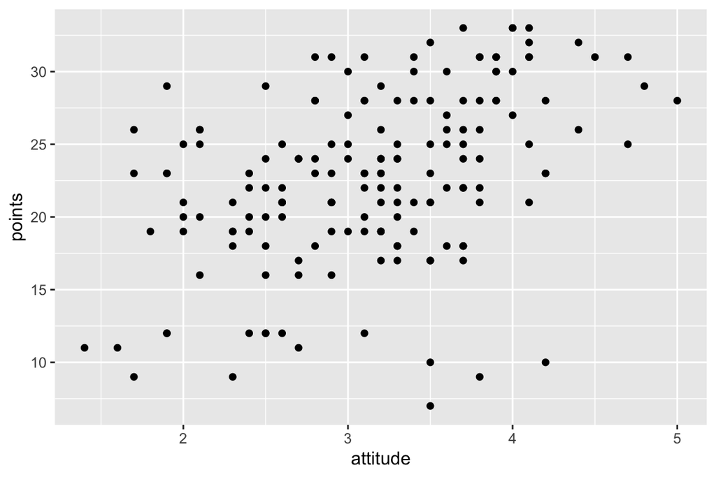

```r
learning2014 <- read.table("https://raw.githubusercontent.com/KimmoVehkalahti/Helsinki-Open-Data-Science/master/datasets/learning2014.txt",sep=",", header=TRUE)
library(ggplot2)
p1 <- ggplot(learning2014, aes(x = attitude, y = points))
p2 <- p1 + geom_point()
p2
```

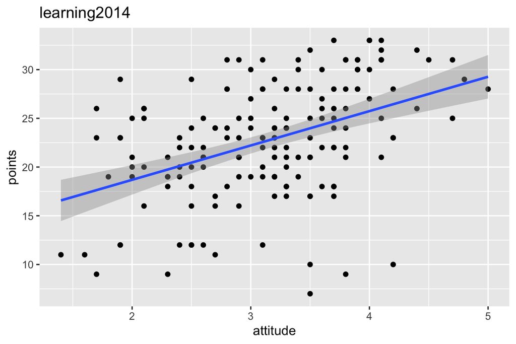

```r
p3 <- p2 + geom_smooth(method = "lm")
p4 <- p3 + ggtitle("learning2014")
p4
```

## Question 3: Correlations

But what factors - age, sex, attitude (or any subdivision thereof, including responses to deep, surface level, or strategic questions) has the greatest correalation with points received on the final exam?

An analysis of the correlations between the pairs of variables available to us shows that of all the possible pairings of variables, **students’ *attitude* correlated most strongly with their score**, suggesting that other variables, including age and sex, did not have as strong an effect on their final score.

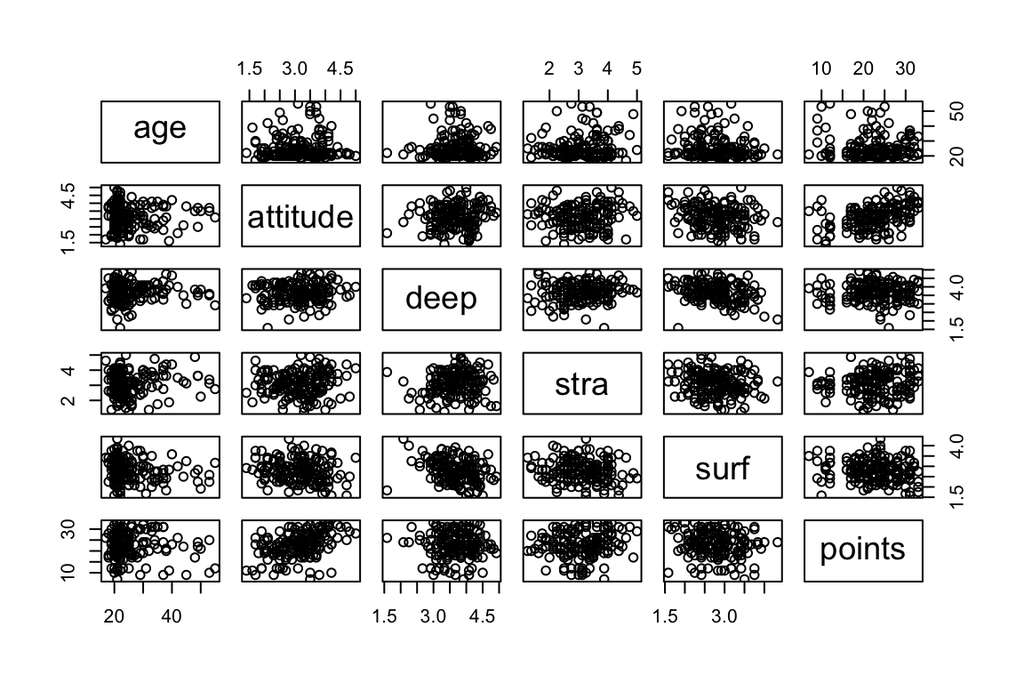

```r
learning2014 <- read.table("https://raw.githubusercontent.com/KimmoVehkalahti/Helsinki-Open-Data-Science/master/datasets/learning2014.txt",sep=",", header=TRUE)
library(ggplot2)
pairs(learning2014[-1])
```

```r
library(GGally)
```

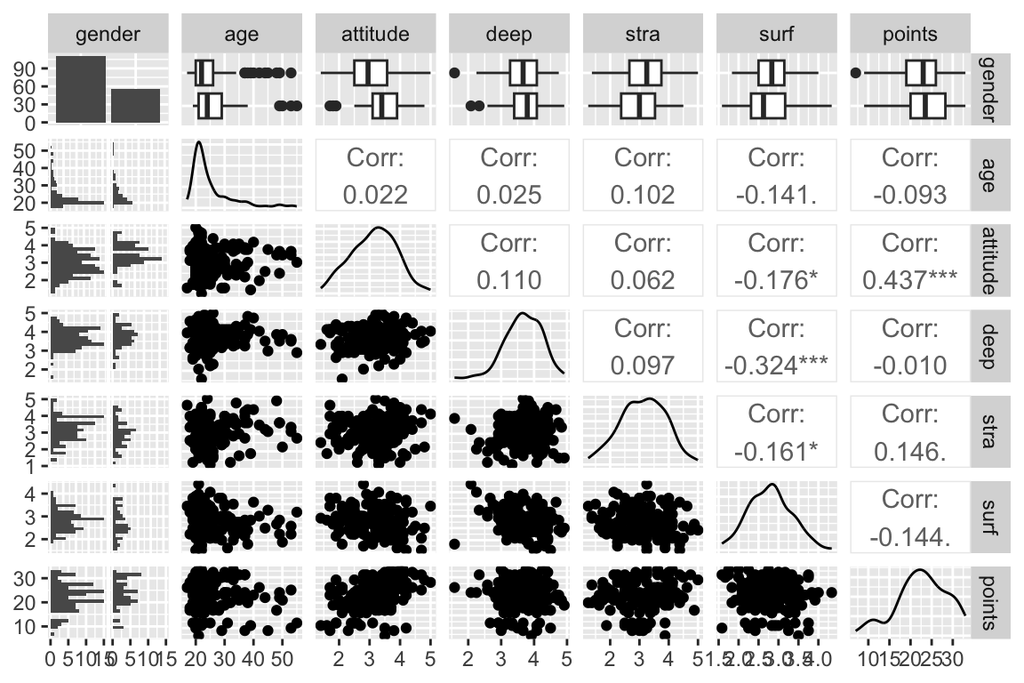

```r
library(ggplot2)
p <- ggpairs(learning2014, mapping = aes(), lower = list(combo = wrap("facethist", bins = 20)))
p
```

## Remaining questions

Sorry, I was unable to get to the final parts of this assignment! I hope to be able to catch up eventually, but for now, this is as far as I managed to get!

# Chapter 3: Analysis

First, I will load a data package, provided by Kimmo Vehkalahti for assignment 3. See the R code below.

### R code

```r
alc <- read.table("https://raw.githubusercontent.com/KimmoVehkalahti/Helsinki-Open-Data-Science/master/datasets/alc.csv", sep = "," , header = TRUE)

# Print out the names of the variables in the data

colnames(alc)
```

```
##  [1] "school"     "sex"        "age"        "address"    "famsize"
##  [6] "Pstatus"    "Medu"       "Fedu"       "Mjob"       "Fjob"
## [11] "reason"     "guardian"   "traveltime" "studytime"  "schoolsup"
## [16] "famsup"     "activities" "nursery"    "higher"     "internet"
## [21] "romantic"   "famrel"     "freetime"   "goout"      "Dalc"
## [26] "Walc"       "health"     "failures"   "paid"       "absences"
## [31] "G1"         "G2"         "G3"         "alc_use"    "high_use"
```

#### Description of the initial data

The data set used for this exercise originally comes from not one data set, but two data sets combined into one.

The original two data sets are from surveys of Portuguese high school students from two different schools: Gabriel Pereira (or “GP” in the school column of the data), and Mousinho da Silveira (or “MS” in the school column). The data sets describe around two dozen categories of demographic criteria (including the size of their family, their sex, age, and address, or even their romantic relationship status and weekly alcohol consumption), as well the student’s academic performance, including information about their number of school absences, and their grades in two different glasses: math, and Portuguese.

The combined data set retains most of the original variables of student information, but will be used here to primarily focus on the student’s *alcohol consumption* and *how their alcohol consumption affects other factors*.

### What causes high, and low, alcohol consumption in these sets of Portugeuse high school students?

The purpose of this analysis is to study the relationships between alcohol consumption and some of the other variables in the data. What causes high alcohol consumption? What causes low alcohol consumption? Does low alcohol consumption correlate with high academic performance? Or is alcohol, generally used as a social drug, a function of the student’s relationship with friends, or family?

There are many possible explanations for a student’s alcohol consumption. And while we have rather rich information about each student’s personal life, we only have a limited number of data points. We might hypothesize that, for example, a student’s family income level is a major predictor of alcohol consumption. One 2015 [study](https://www.teensavers.com/post/family-income-affects-teenage-drinking) from the UK showed that middle-income families were far more likely to consume alcohol than those of low-income families. Another [study](https://news.gallup.com/poll/184358/drinking-highest-among-educated-upper-income-americans.aspx) from the United States, also from 2015, showed that educated, upper-income Americans drink more than those in lower income brackets.

However, the data available does not show the student’s income. We could, however, use proxy data that is, perhaps, related to a factor that we are interested in, like the parent’s education level. We might speculate, reasonably, that higher levels of education in parents implies a higher income for the family.

For this analysis, we will explore a number of interesting factors, to see which has the greatest correlation with high alcohol consumption. Specifically, we will examine *high alcohol consumption* and how it is affected by the following four variables:

1. Parent’s cohabitation status [Pstatus]
2. Number of school absences [absences]
3. Going out with friends [goout]
4. Mother’s education level [Medu]

These variables were chosen to sample a variety of implied causal hypothesis:

1. Parent’s cohabitation status: students whose parents live apart will have a higher alcohol consumption rate than those whose parents live to together.
2. Number of school absences: students with a higher number of absences from school will have a higher alchol consumption rate than those with a lower number of school absences.
3. Going out with friends: students who go out more with friends will have a higher alcohol consumption than those who go out less.
4. Mother’s education level: students whose mother has a higher education level will have a higher alcohol consumption rate than those whose mother has a lower education level.

We should be wary, however, of the temptation to infer too much from our data. If we test for correlations between the education level of the parents, and the student’s alcohol consumption, then *we can only speak about the relationship between the two tested variables, and nothing else!* Any other speculations would be nothing more than an educated guess, informed by our analysis of the data we have!

### Numerical and graphical exploration

Our data has a category called “high_use”, classifying the student either as someone who uses a high amount of alcohol, or not. To clarify, the definition of “high use” is based on other data, also given in the table. Essentially, “high use” is a student who has more than 2 drinks on average during both weekdays and weekends. Our data provides the number of drinks students have on weekdays, and the number of drinks they have on weekends. Their overall average alcohol use, another column provided in our data table, called “alc_use”, is the average of their weekday and weekend, alcohol use. Those whose “alc_use” is greater than 2 are categorized as “high_use” students. We will therefore use the “high_use” category as a simple measure of whether the students consume high amounts of alcohol compared to their peers.

#### Variable 1: Parent’s cohabitation status and student high alcohol consumption

“High alcohol use” is a binary category, and so is the first variable we are interested in examining: parent’s cohabitation status. In the data, parent’s cohabitation status is expressed as either ‘T’ for living together, or ‘A’ for living apart. To perform a simple comparison, we will use a cross table to visualize the two variables.

```r
table(high_use = alc$high_use, pstatus = alc$Pstatus)
```

```
##         pstatus
## high_use   A   T
##    FALSE  26 233
##    TRUE   12  99
```

First, note that a far greater number of students parents are together “T” than apart “A”. However, through some simple arithmetic, we can see that 29.8 percent of those whose parents are together are high users alcohol, compared to a slightly higher while 31.6 percent of those whose parents are apart. This shows that the likelihood of high alcohol use is higher in those whose parents are apart, but not by much at all.

#### Variable 2: Absences and student high alcohol consumption

One might expect those with high alcohol consumption to also have a high number of absences from school - either because students are out partying, rather than going to school, or perhaps lounging at home nursing a hangover!

See the box plot below for a correlation of the number of absences from school along the y-axis, and whether the student is a high alcohol user - true or false - along the x-axis.

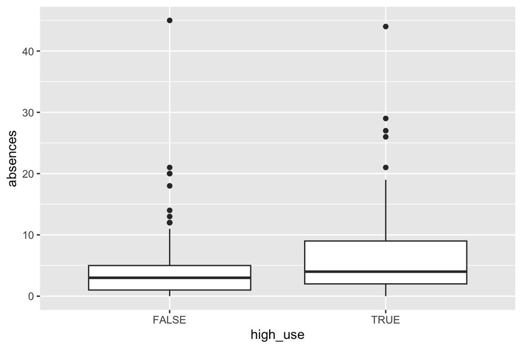

```r
library(ggplot2)
g1 <- ggplot(alc, aes(x = high_use, y = absences))
g1 + geom_boxplot() + ylab("absences")
```

As may have been expected, there is higher number of absences on average in high users, but not by much, however. The center black line of the box plot represents the 50th percentile for the group, and the 50th percentile is not much higher in the high user category than than the non-high users. However, there 75th percentile is significantly higher among high-users.

One might summarize by saying that *of* those students with a high number of absences, they are more likely to be high alcohol user. However, note that the highest outlier is actually in the false, non-high alcohol user, category, a trivial but nonetheless interesting detail.

#### Variable 3: Going out with friends

Drinking is generally a social phenomenon, a social lubricant, as it were, and so it might be expected that the more high schoolers go out with friends, the more likely they are to drink a significant amount. Our data on how often students go out with friends is ranked on a five point scale, where 1 = very low and 5 = very high.

```r
library(magrittr)
table(high_use = alc$high_use, goout = alc$goout) %>% addmargins()
```

```
##         goout
## high_use   1   2   3   4   5 Sum
##    FALSE  19  82  97  40  21 259
##    TRUE    3  15  23  38  32 111
##    Sum    22  97 120  78  53 370
```

Here, we can see that of those who are high users of alcohol, here the TRUE values, 63 percent of them are either 4s or 5s on the “going out” scale, a strong correlation. By contrast, only 23 percent of non-heavy drinkers, those in the FALSE category, were 4s and 5s (those who go out with friends the most). “3” was the most common anwser among those who were not heavy drinkers, while “4” was teh most common answer among high alcohol users.

#### Variable 4: Mother’s education level and alcohol use

Mother’s education level is a five-level numbered scale from 0 to 4, where 0 signifies no education, 1 represents a primary school level education (through 4th grade in Portugal), 2 represents a 5th through 9th grade education, 3 represents a secondary education and 4 represents higher education. The mother’s education level could represent a number of factors, though the relationship to alcohol use is perhaps unclear. Again, we might speculate that mothers with higher education levels mean that students in these households have higher income, but this is merely a guess.

```r
table(high_use = alc$high_use, goout = alc$Medu) %>% addmargins()
```

```
##         goout
## high_use   0   1   2   3   4 Sum
##    FALSE   1  31  78  57  92 259
##    TRUE    2  18  18  36  37 111
##    Sum     3  49  96  93 129 370
```

In both high use students, and non-high use students, mothers with higher education levels were the highest category. However, 65.8 percent of high use students had mothers with either a secondary or higher education level, while only 57.5 percent of non high use students had mothers with either a higher education or secondary education level. This indicates a marginally stronger correlation between mothers higher education level, and high use drinking.

#### Preliminary observations, reflection on hypothesis

Of all the variables, it appears that the whether students go out with friends has the highest correlation with high use of alcohol, followed by absences. This is somewhat surprising, considering all the possible variables, though it is difficult with these rudimentary means to compare the strength of correlations between each variable.

### Using logistic regression

We will now use logistic regression to create a model of our data, asking about the relationship between high alcohol use and our four variables: parent status, absences, going out with friends and mother’s education level.

#### Present and interpret a summary of the fitted model.

Below in the R code, we have entered our variables into a code that yields a logistic regression model.

```r
m <- glm(high_use ~ Pstatus + absences + goout + Medu, data = alc, family = "binomial")

summary(m)
```

```
##
## Call:
## glm(formula = high_use ~ Pstatus + absences + goout + Medu, family = "binomial",
##     data = alc)
##
## Deviance Residuals:
##     Min       1Q   Median       3Q      Max
## -1.9109  -0.7529  -0.5452   0.9390   2.3849
##
## Coefficients:
##             Estimate Std. Error z value Pr(>|z|)
## (Intercept) -3.37421    0.66203  -5.097 3.45e-07 ***
## PstatusT    -0.01183    0.41275  -0.029  0.97713
## absences     0.07778    0.02258   3.445  0.00057 ***
## goout        0.73908    0.11824   6.251 4.08e-10 ***
## Medu        -0.09754    0.11735  -0.831  0.40587
## ---
## Signif. codes:  0 '***' 0.001 '**' 0.01 '*' 0.05 '.' 0.1 ' ' 1
##
## (Dispersion parameter for binomial family taken to be 1)
##
##     Null deviance: 452.04  on 369  degrees of freedom
## Residual deviance: 389.60  on 365  degrees of freedom
## AIC: 399.6
##
## Number of Fisher Scoring iterations: 4
```

```r
coef(m)
```

```
## (Intercept)    PstatusT    absences       goout        Medu
## -3.37421435 -0.01183365  0.07778412  0.73907621 -0.09753627
```

# Chapter 4: Clustering and Classification

Due: Tue Nov 29 09:00 2022

## 1. R markdown file created

## 2. Loading the data, describing the data set

In this exercise, we will use a data set describing aspects of the city of Boston, in the United States, in a study conducted in 1978 by Harrison and Rubinfeld.

```r
library(MASS)
library(tidyr)
```

```r
library(corrplot)
data("Boston")
```

```r
str(Boston)
```

```
## 'data.frame':    506 obs. of  14 variables:
##  $ crim   : num  0.00632 0.02731 0.02729 0.03237 0.06905 ...
##  $ zn     : num  18 0 0 0 0 0 12.5 12.5 12.5 12.5 ...
##  $ indus  : num  2.31 7.07 7.07 2.18 2.18 2.18 7.87 7.87 7.87 7.87 ...
##  $ chas   : int  0 0 0 0 0 0 0 0 0 0 ...
##  $ nox    : num  0.538 0.469 0.469 0.458 0.458 0.458 0.524 0.524 0.524 0.524 ...
##  $ rm     : num  6.58 6.42 7.18 7 7.15 ...
##  $ age    : num  65.2 78.9 61.1 45.8 54.2 58.7 66.6 96.1 100 85.9 ...
##  $ dis    : num  4.09 4.97 4.97 6.06 6.06 ...
##  $ rad    : int  1 2 2 3 3 3 5 5 5 5 ...
##  $ tax    : num  296 242 242 222 222 222 311 311 311 311 ...
##  $ ptratio: num  15.3 17.8 17.8 18.7 18.7 18.7 15.2 15.2 15.2 15.2 ...
##  $ black  : num  397 397 393 395 397 ...
##  $ lstat  : num  4.98 9.14 4.03 2.94 5.33 ...
##  $ medv   : num  24 21.6 34.7 33.4 36.2 28.7 22.9 27.1 16.5 18.9 ...
```

The structure of the data, shown above, gives us a brief look at the data, and some of its values. The variables in the data are listed there along the left hand side. Here is a full read out of the data, so that you will be able to recognize the variables by their abbreviated names when they are used through this report:

crim per capita crime rate by town.

zn proportion of residential land zoned for lots over 25,000 sq.ft.

indus proportion of non-retail business acres per town.

chas Charles River dummy variable (= 1 if tract bounds river; 0 otherwise).

nox nitrogen oxides concentration (parts per 10 million).

rm average number of rooms per dwelling.

age proportion of owner-occupied units built prior to 1940.

dis weighted mean of distances to five Boston employment centres.

rad index of accessibility to radial highways.

tax full-value property-tax rate per $10,000.

ptratio pupil-teacher ratio by town.

black 1000(Bk - 0.63)^2 where Bk is the proportion of blacks by town.

lstat lower status of the population (percent).

medv median value of owner-occupied homes in $1000s.

```r
dim(Boston)
```

```
## [1] 506  14
```

In total, the data table has 506 rows, and 14 columns. Each of the rows represents a town, while each of 14 variables describe one of the variables listed above, like the town’s crime rate per capita (crim), average rooms per dwelling (rm), pupil-teacher ratio by town (“ptratio”), and other interesting demographic data.

## 3. Graphical overview, description of relationships

### Graph: Plot Matix

```r
library(MASS)
data("Boston")
summary(Boston)
```

```
##       crim                zn             indus            chas
##  Min.   : 0.00632   Min.   :  0.00   Min.   : 0.46   Min.   :0.00000
##  1st Qu.: 0.08205   1st Qu.:  0.00   1st Qu.: 5.19   1st Qu.:0.00000
##  Median : 0.25651   Median :  0.00   Median : 9.69   Median :0.00000
##  Mean   : 3.61352   Mean   : 11.36   Mean   :11.14   Mean   :0.06917
##  3rd Qu.: 3.67708   3rd Qu.: 12.50   3rd Qu.:18.10   3rd Qu.:0.00000
##  Max.   :88.97620   Max.   :100.00   Max.   :27.74   Max.   :1.00000
##       nox               rm             age              dis
##  Min.   :0.3850   Min.   :3.561   Min.   :  2.90   Min.   : 1.130
##  1st Qu.:0.4490   1st Qu.:5.886   1st Qu.: 45.02   1st Qu.: 2.100
##  Median :0.5380   Median :6.208   Median : 77.50   Median : 3.207
##  Mean   :0.5547   Mean   :6.285   Mean   : 68.57   Mean   : 3.795
##  3rd Qu.:0.6240   3rd Qu.:6.623   3rd Qu.: 94.08   3rd Qu.: 5.188
##  Max.   :0.8710   Max.   :8.780   Max.   :100.00   Max.   :12.127
##       rad              tax           ptratio          black
##  Min.   : 1.000   Min.   :187.0   Min.   :12.60   Min.   :  0.32
##  1st Qu.: 4.000   1st Qu.:279.0   1st Qu.:17.40   1st Qu.:375.38
##  Median : 5.000   Median :330.0   Median :19.05   Median :391.44
##  Mean   : 9.549   Mean   :408.2   Mean   :18.46   Mean   :356.67
##  3rd Qu.:24.000   3rd Qu.:666.0   3rd Qu.:20.20   3rd Qu.:396.23
##  Max.   :24.000   Max.   :711.0   Max.   :22.00   Max.   :396.90
##      lstat            medv
##  Min.   : 1.73   Min.   : 5.00
##  1st Qu.: 6.95   1st Qu.:17.02
##  Median :11.36   Median :21.20
##  Mean   :12.65   Mean   :22.53
##  3rd Qu.:16.95   3rd Qu.:25.00
##  Max.   :37.97   Max.   :50.00
```

Here we have a summary of some of the basic features of our data about Boston in the 1970s. Take a look at the first variable, “crim”, or per capita crime rate by town. We can infer that in Boston, the vast majority of towns have a relatively low crime rate, while there are a small number of towns with much higher than average rates. The value for the first quantile, or lowest 25 percent of the data, is 0.0825. The mean is 3.61, and the third quantile - from 50 percent to 75 percent of the data - is just 3.67. Not much higher. The max, however, is 88.9, indicating that there is at least one neighborhood with a crime rate significantly higher than all the rest!

### Graph: Correlation Matix

Now we are going to look at the basic relationships between the variables using a correlation plot. The plot compares the correlation of each individual variable to the others, and tells us “for how much in the *increase* of one variable, do we get an *increase* or *decrease* in another variable?” Our correlation plot read out is a bit more fancy than usual, and has a color-coded legend on the right.

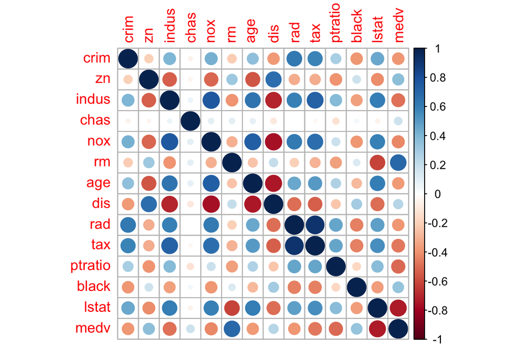

```r
library(MASS)
library(tidyr)
library(corrplot)
data("Boston")
cor_matrix <- cor(Boston)
corrplot(cor_matrix, method="circle")
```

Deep blue represents strong correlations - one to one, that is - while deep red represents strong negative correlations - one to negative one. Have a look at the correlations for median value of owner-occupied homes in $1000s (medv). We can follow either along vertical medv row, or horizontal medv column. One strong blue dot lies on the intersection between “medv” and “rm”, the average number of rooms per dwelling. This makes sense, as the higher the average housing value in a neighborhood, the more likely it is to have more rooms. There’s a strong red dot in the medv column or row, which is its intersection with “lstat”, or lower status of the population. In Harrison and Rubinfeld’s [study](https://deepblue.lib.umich.edu/bitstream/handle/2027.42/22636/0000186.pdf;jsessionid=467069C0C6838F993569E4E3EFA41722?sequence=1) lstat is defined thusly: the proportion of population that is lower status = 1/2 (proportion of adults without some high school education and proportion of male workers classified as laborers)

## 4. Standardizing the data

### Scaling the data

Now that we understand a bit about what our data in Boston includes, we have a problem: even though all our data are measured as numerics, how can we better compare one measure to another across the data table? We have several different variables, each with their own wildly different number measure. Some measures of proportion range between zero and one, while other raw measures in other variable columns output in the hundreds.

We will therefore standardize our data by scaling it. Notice what happens to our values in our new scaled data table, using the function scale() in R.

```
##       crim                 zn               indus              chas
##  Min.   :-0.419367   Min.   :-0.48724   Min.   :-1.5563   Min.   :-0.2723
##  1st Qu.:-0.410563   1st Qu.:-0.48724   1st Qu.:-0.8668   1st Qu.:-0.2723
##  Median :-0.390280   Median :-0.48724   Median :-0.2109   Median :-0.2723
##  Mean   : 0.000000   Mean   : 0.00000   Mean   : 0.0000   Mean   : 0.0000
##  3rd Qu.: 0.007389   3rd Qu.: 0.04872   3rd Qu.: 1.0150   3rd Qu.:-0.2723
##  Max.   : 9.924110   Max.   : 3.80047   Max.   : 2.4202   Max.   : 3.6648
##       nox                rm               age               dis
##  Min.   :-1.4644   Min.   :-3.8764   Min.   :-2.3331   Min.   :-1.2658
##  1st Qu.:-0.9121   1st Qu.:-0.5681   1st Qu.:-0.8366   1st Qu.:-0.8049
##  Median :-0.1441   Median :-0.1084   Median : 0.3171   Median :-0.2790
##  Mean   : 0.0000   Mean   : 0.0000   Mean   : 0.0000   Mean   : 0.0000
##  3rd Qu.: 0.5981   3rd Qu.: 0.4823   3rd Qu.: 0.9059   3rd Qu.: 0.6617
##  Max.   : 2.7296   Max.   : 3.5515   Max.   : 1.1164   Max.   : 3.9566
##       rad               tax             ptratio            black
##  Min.   :-0.9819   Min.   :-1.3127   Min.   :-2.7047   Min.   :-3.9033
##  1st Qu.:-0.6373   1st Qu.:-0.7668   1st Qu.:-0.4876   1st Qu.: 0.2049
##  Median :-0.5225   Median :-0.4642   Median : 0.2746   Median : 0.3808
##  Mean   : 0.0000   Mean   : 0.0000   Mean   : 0.0000   Mean   : 0.0000
##  3rd Qu.: 1.6596   3rd Qu.: 1.5294   3rd Qu.: 0.8058   3rd Qu.: 0.4332
##  Max.   : 1.6596   Max.   : 1.7964   Max.   : 1.6372   Max.   : 0.4406
##      lstat              medv
##  Min.   :-1.5296   Min.   :-1.9063
##  1st Qu.:-0.7986   1st Qu.:-0.5989
##  Median :-0.1811   Median :-0.1449
##  Mean   : 0.0000   Mean   : 0.0000
##  3rd Qu.: 0.6024   3rd Qu.: 0.2683
##  Max.   : 3.5453   Max.   : 2.9865
```

```
## [1] "matrix" "array"
```

Notice that our data have a much tighter absolute range in their values, across *all* variables in the data set. We can find no minimum, in any category less than -10, and no positive maximum value higher than 10. In fact, the highest maximum in our scaled data is 9.92, the maximum of “crim”. In our previous data set, it was around 88.98.

The data as more “smooth”, in a way, now that it is scaled, so that we can better compare variations in each variable of our data against oneanother.